# Homework 3

Araks Karapetyan

October 8, 2017

(1 point) Read the file Attrition.csv into R. The general objective of this analysis will be predicting the whether certain employees will quit their job at this company or not (which is reflected in Attrition variable). First, ckeck whether the variables have right data types, , make appropriate corrections, if needed.

```r
attrition <- read.csv("Attrition2.csv")
attrition
```

[output not shown]

[output cut: 2341 more lines]

```r
summary(attrition)
```

```
##  Attrition   DailyRate      EnvironmentSatisfaction    JobLevel
##  No :987   Min.   : 102.0   Min.   :1.000           Min.   :1.00
##  Yes:190   1st Qu.: 465.0   1st Qu.:2.000           1st Qu.:1.00
##            Median : 804.0   Median :3.000           Median :2.00
##            Mean   : 801.8   Mean   :2.717           Mean   :2.09
##            3rd Qu.:1162.0   3rd Qu.:4.000           3rd Qu.:3.00
##            Max.   :1499.0   Max.   :4.000           Max.   :5.00
##  OverTime  StockOptionLevel TotalWorkingYears YearsInCurrentRole
##  No :841   Min.   :0.0000   Min.   : 0.0      Min.   : 0.000
##  Yes:336   1st Qu.:0.0000   1st Qu.: 6.0      1st Qu.: 2.000
##            Median :1.0000   Median :10.0      Median : 3.000
##            Mean   :0.8012   Mean   :11.4      Mean   : 4.205
##            3rd Qu.:1.0000   3rd Qu.:15.0      3rd Qu.: 7.000
##            Max.   :3.0000   Max.   :40.0      Max.   :18.000
```

```r
attrition$EnvironmentSatisfaction <- factor(attrition$EnvironmentSatisfaction, levels = c(1:4), labels = c("low", "medium", "high", "very high"))
attrition$JobLevel <- factor(attrition$JobLevel, levels = c(1:5), labels = c("lowest", "low", "medium", "high", "highest"))
attrition$StockOptionLevel <- factor(attrition$StockOptionLevel)
```

(4 points) Explore the relationship between the variables OverTime and Attrition. First calculate what is the probability that an employee leaves the company given that he/she worked overtime. Second, using ggplot2 construct a barplot to show the relationship between these variables (based on probabilities of attrition) Third, construct a barplot illustrating the relationship between Environment Satisfaction and Attrition Comment on all the results

```r
addmargins(table(attrition$OverTime, attrition$Attrition))
```

```
##
##         No  Yes  Sum
##   No   751   90  841
##   Yes  236  100  336
##   Sum  987  190 1177
```

```r
#The probability that an employee leaves the company given that he/she worked overtime is 100/336 = 0.2976.

Probs <- as.data.frame(prop.table(table(attrition$OverTime, attrition$Attrition), 1))
Probs
```

```
##   Var1 Var2      Freq
## 1   No   No 0.8929845
## 2  Yes   No 0.7023810
## 3   No  Yes 0.1070155
## 4  Yes  Yes 0.2976190
```

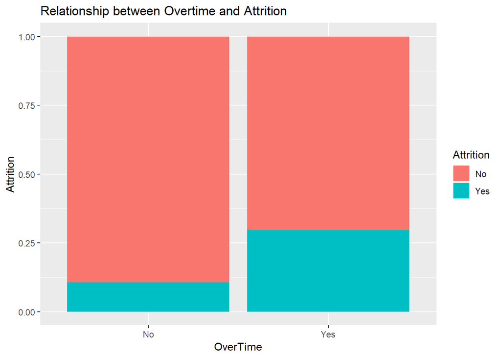

```r
library(ggplot2)
ggplot(Probs, aes(x = Var1, y = Freq, fill = Var2))+geom_bar(stat = "identity", position = "fill")+labs(x = "OverTime", y = "Attrition", fill = "Attrition",title = "Relationship between Overtime and Attrition")
```

```r
#From the first barplot we can state that the people who worked overtime are more likely to leave their jobs than the people who did not work overtime.

Probs1 <- as.data.frame(prop.table(table(attrition$EnvironmentSatisfaction, attrition$Attrition), 1))
Probs1
```

```
##        Var1 Var2      Freq
## 1       low   No 0.7489177
## 2    medium   No 0.8622222
## 3      high   No 0.8610354
## 4 very high   No 0.8587571
## 5       low  Yes 0.2510823
## 6    medium  Yes 0.1377778
## 7      high  Yes 0.1389646
## 8 very high  Yes 0.1412429
```

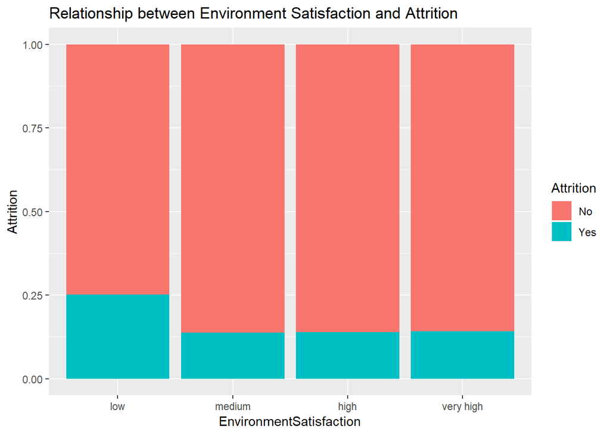

```r
ggplot(Probs1, aes(x = Var1, y = Freq, fill = Var2))+geom_bar(stat = "identity")+labs(x = "EnvironmentSatisfaction", y = "Attrition", fill = "Attrition", title = "Relationship between Environment Satisfaction and Attrition")
```